# R Exercises for QF

Xu Liu

- The exercises within this session are intended to apply elements learned throughout chapters 1-5 of the Introductory Course on R to simple and practical situations that could be part of daily work activities. The exercises include a first part to practice the whole process from downloading financial data (equity and fixed-income) within R, processing the data, extracting summary statistics, plotting graphs and exporting data/graphs to other formats (excel, pdf, jpg, etc.). A second part focuses on calculating Value at Risk (VaR) of an equity index and of a portfolio of stocks.

# 1 PART 1

Required packages

- **quantmod**: `quantmod` is a quantitative financial modelling package for R, which is widely used both by researchers and practitioners to manage quantitative financial modelling workflows. It can also be used to easily download financial data from online databases, such as Yahoo Finance and FRED. Additional functionalities can be found in https://cran.r-project.org/web/packages/quantmod/quantmod.pdf.
  - Remember: `install.packages("quantmod")`

## 1.1 Exercise 1.1

- Target: Download, analyze and export data from the Shanghai Composite Index
- Use function `getSymbols()` to download data. When used for equities, this function by default will download opening price, highest price, lowest price, closing price, traded volume, and closing price adjusted for splits and dividends.
  - Its syntax is:

  `getSymbols ("ticker", src= "yahoo, FRED, etc.", from = "yyyy-mm-dd", to= "yyyy-mm-dd", auto.assign=F)`

  Note that setting `auto assign` as `false` will return the results instead of loading them to the environment. Enter R> `?getSymbols` to see more on the syntax.(To see ?getSymbols, *quantmod* package needs to be loaded first)
- Download data from **yahoo** on the Shanghai Composite Index (ticker: “**000001.SS**”) from **2018-06-28** to **2019-06-26**. Define the data as **SHC**.
  - *Hint*: R> SHC = getSymbols(…)
- Export the data to an excel file and name the first sheet as `SHC_price`
  - *Hint*: R> write.xlsx(SHC, file=“filename.xlsx”, sheetName=“SHC_price”)
- Fill in the following information from data series `SHC`:

  | data | answer | data | answer |
  | --- | --- | --- | --- |
  | How many lines of data |  | Highest price |  |
  | Open price in 2018-07-02 |  | Lowest close price |  |
  | Close price in 2019-6-25 |  | Lowest price |  |
  | Highest close price |  | Mean of close price |  |

## 1.2 Exercise 1.2

- Target: Plot a chart of the Shanghai Composite Index
- Plot a graph showing the closing price of SHC using the `plot()` command
  - *Hint*: remember that the sign `$` can be used to specify a column. For instance: `SHC$"000001.SS.Close"` refers to the closing price column. Alternatively, the same column could be referred as `SHC[ line, column]`.
- Plot the **volume** traded of SHC using the `plot()` and add a **title** to the chart
  - Syntax: plot(data, main=“title”)
  - Click **zoom** for the chart to pop out
- Plot a graph of SHC using the `chartSeries()` command. While plot() is a standard command built in R, `chartSeries()` is a command that comes with package `quantmod`. By default, it will plot the closing price and volume of a given time series.
  - Have fun: Moving Average Convergence Divergence (MACD) lines can be added to the chart by entering R> `addMACD()`, Bollinger Bands using `addBBands()`, Directional Movement Indicator using `addADX()`, Chaikin Money Flow (CMF) using `addCMF()`.
- Plot a histogram of the volume traded of SHC, dividing the frequency into **25** breaks
  - Command *hist()* has the syntax `hist(data series, breaks= # of breaks)`.
  - *Hint*: select the column that contains volume traded using `$` or `[row, column]`
- Save one chart as **image** and one chart as **pdf** using functions *png()*, *jpeg()* and/or *pdf()*
  - *Hint*: First step is to enter command jpeg(“file_name.jpg”) to open the request to save an image. Second step is to create the chart that you wish to save. Final step is to execute the request using function dev.off() to save the chart.

## 1.3 Exercise 1.3

- Target: Calculate the returns of investments in Shanghai Composite Index
- Returns of a given security can be retrieved using functions **dailyReturn(), weeklyReturn(), monthlyReturn(), yearlyReturn(), allReturns()**.
  - Syntax is simple, for instance: `dailyReturn("data")`
- Calculate daily and weekly returns. Name them as `daily_rets` and `weekly_rets`
- Use the function `View()` to view the daily returns in the upper part of R Studio
- Use function `print()` to view the monthly returns in the lower part of R Studio
- Use functions `seriesHi()` and `seriesLo()` to see the highest and lowest daily and weekly returns
- Use function `plot()` to see a graph of the monthly returns
- Save the daily and weekly return data into new sheets of the same excel file created in exercise 1.1
  - *Hint*: R> write.xlsx(“daily_rets”, file=“same file name”, sheetName = “SHC_return”, append=T)
- Enter the following return information about Shanghai Composite Index:

  | data | answer |
  | --- | --- |
  | Highest daily return (%) |  |
  | Highest daily return (date) |  |
  | Lowest weekly return (%) |  |
  | Lowest weekly return (date) |  |
  | Highest monthly return (%) |  |
  | Highest monthly return (date) |  |

## 1.4 Exercise 1.4

- Target: Download, analyze and export US bond yield data
- Use function `getSymbols()` to download data from **FRED** on US 10-year government bonds (ticker: “**DGS10**”). Define data as `UST10YR`.
  - Syntax is: *R> getSymbols (“ticker”, src= “yahoo, FRED, etc.”, from = “yyyy-mm-dd”, to= “yyyy-mm-dd”, auto.assign=F)*
  - If start and end dates are not specified, the whole dataset will be downloaded
- Check the US 10-year bond yield in 1980-October-15
  - *Hint*: enter UST10YR[“YYYY-MM-DD”]
- Check the US 10-year bond yield in 1995-May
  - *Hint*: enter UST10YR[“YYYY-MM”]
- Check the US 10-year bond yield between 2000-Jan-18 and 2000-Feb-10
  - *Hint*: enter UST10YR[“YYYY-MM-DD::YYYY-MM-DD”]
- Export the data series to an **excel** file
- Plot bond yields using function `plot()`
  - Try exploring other elements within this function, such as: R> `plot(data, main="title of graph", col="blue")`
- Enter the following information about the time series you just downloaded:

  | data | answer |
  | --- | --- |
  | How many lines of data |  |
  | Highest yield |  |
  | Lowest yield |  |
  | Average yield |  |
  | Yield on 1980-04-25 |  |
  | Mean yields in 2019-March |  |
  | Highest yield between 2018-02-22 and 2018-03-10 |  |

  - *Hints*: `mean()` can be used to find the average of a time series, while `max()` can be used to find the highest value and `min()` the lowest value. R may not perform certain functions if there are missing values (`NA`) in the data set. You can override, for instance, by applying *R> mean(data, na.rm=TRUE)*.

## 1.5 Exercise 1.5

- Target: Download and analyze data on Aaa and Baa-rated bonds
- Use function `getSymbols()` to download data from **FRED** on Aaa-rated (ticker:“**AAA**”) and Baa-rated (“**BAA**”) bonds.
  - Syntax is: *R> getSymbols (“ticker”, src= “yahoo, FRED, etc.”, from = “yyyy-mm-dd”, to= “yyyy-mm-dd”, auto.assign=F)*
- Calculate the spread between BAA and AAA bonds and name the data frame as `spread`
  - *Hint*: This is a simple operation that can be done as *R> spread= BAA - AAA*
- Merge AAA, BAA and spread time series. Name it as `yld_data`
  - *Hint*: yld_data = merge(AAA, BAA, spread)
- See the first values of the time series using function `head()`
- Change column titles to AAA_yields, BBB_yields and spread
  - *Hint*: Use command colnames(yld_data)[column number] = “column title”
- Check in which date(s) the spread was **3.38**
  - *Hint*: use command time(yld_data)[spread==3.38]
- Check periodicity of data using command `periodicity()`
- Plot the spread from 2005 to date
- Enter the following information about the time series:

  | data | answer |
  | --- | --- |
  | Min, Avg., Max AAA yield |  |
  | Min, Avg. Max spread |  |
  | Max spread in 2019 |  |
  | Min Baa yield before 2000 |  |
  | Dates when AAA was 3.5 |  |
  | Date when spread was 3.38 |  |
  | Correlation between AAA and BAA from 1980 to 2000 |  |
  | Correlation between AAA and BAA after 2015 to date |  |

  - Remember: Use command `cor(x,y)` to calculate correlations

# 2 PART 2

Required packages

- **PerformanceAnalytics**: `PerformanceAnalytics` is an R package that contains a collection of econometric functions for performance and risk analysis of financial instruments or portfolios. Some of its functions include Value at Risk (VaR), expected shortfall, Calmar reward/risk ratio, Sharpe and adjusted Sharpe ratio, Sortino ratio, Fama“s Beta, Modigliani”s measure, skewness kurtosis ratio, active return, etc.

## 2.1 Exercise 2.1

- Target: Calculate Value at Risk (**VaR**) of a portfolio invested in Shanghai Composite

**Concept**

**Value at risk (VaR)** is a measure of the risk of loss for investments. It estimates how much a set of investments might lose in a set time period such as a day. **VaR** is typically used by firms and regulators in the financial industry to gauge the amount of assets needed to cover possible losses. More formally, **p VaR** is defined such that the probability of a loss greater than VaR is (at most) **p** while the probability of a loss less than VaR is (at least) **1-p**. For example, if a portfolio of stocks has a one-day 5% VaR of $1 million, that means that there is a 0.05 probability that the portfolio will fall in value by more than $1 million over a one-day period. There are different ways of computing VaR, including a historic, parametric (e.g. Gaussian), and simulations (Monte Carlo) methods.

- Use command `VaR()` to compute daily Value at Risk (VaR) of a portfolio invested in the Shanghai Composite in Exercise 1.1 using the **95th** percentile and the **historical method**
  - Command VaR() has the following syntax: `VaR(return data, p=0.95, method="historical")`. The method could also be gaussian, modified, etc.
  - Remember that SHC returns were defined as `daily_rets` and `weekly_rets`
- Function `CVaR()` can be used to calculate Conditional VaR, also known as expected shortfall, using the same syntax as VaR().
- What is the **95th** percentile daily VaR (historical method) of a RMB 1 million portfolio fully invested in the Shanghai Composite? Please use return data of the **past one year**.
  - Answer: _________________
- Now calculate the following VaR:
  - 95th percentile, weekly, historical method: _______________
  - 99th percentile, daily, historical method: _______________
  - 99th percentile, weekly, historical method: _______________
  - 95th percentile, daily, gaussian method: __________________
  - 95th percentile, daily, modified method: __________________

# 3 PRACTICE AT HOME

## 3.1 Exercise 3.1

- Target: Calculate VaR of a portfolio invested in Vale, Petrobras and Cemig
- Create a vector named `tickers` containing the tickers of the stocks in our portfolio composed of Vale (VALE3.SA), Petrobras (PETR4.SA) and Cemig (CMIG4.SA)
  - *Hint*: tickers = c(“ticker 1”, ticker 2", etc)
- Create a vector named `weights` containing the weights of our portfolio.
  - The weights can be **0.35** for Vale, **0.35** for Petrobras and **0.3** for Cemig
  - *Hint*: weights = c(0.35, 0.35, 0.30)
- Download price data for our portfolio, from 2018-06-20 to 2019-06-20.
  - *Hint*: you can use the vector “tickers” directly in getSymbols(). Change the option if necessary.
- Create a time series with the return data for the portfolio and name it `port.returns`
  - *Hint 1*: use port.returns = merge(dailyReturn(VALE3.SA),dailyReturn(…)…)
  - *Hint 2*: change column titles use colnames()
- Calculate daily VaR for the portfolio, using the historical method, 95th percentile, and the weights specified earlier in the vector.
  - *Hint*: VaR(port.returns, p=0.95, weights= weights, portfolio_method= “component”, method=“historical”)

# 4 Solutions

## 4.1 R scripts for exercise 1.1

```r
# R scripts for exercise 1.1
# library(quantmod)
# library(xlsx)

SHC = getSymbols("000001.SS",src="yahoo",from="2018-06-28",to="2019-06-26",auto.assign = F)
write.xlsx(SHC,file="SHCI.xlsx",sheetName="SHC_price")

dim(SHC)
```

```
## [1] 238   6
```

```r
head(SHC)
```

```
##            000001.SS.Open 000001.SS.High 000001.SS.Low 000001.SS.Close
## 2018-06-28       2799.904       2825.987      2782.446        2786.897
## 2018-06-29       2789.811       2848.372      2782.381        2847.418
## 2018-07-02       2841.580       2845.680      2756.815        2775.557
## 2018-07-03       2774.570       2786.888      2722.449        2786.888
## 2018-07-04       2776.632       2793.179      2754.155        2759.126
## 2018-07-05       2755.339       2777.523      2727.940        2733.882
##            000001.SS.Volume 000001.SS.Adjusted
## 2018-06-28           118400           2786.897
## 2018-06-29           125700           2847.418
## 2018-07-02           137000           2775.557
## 2018-07-03           142500           2786.888
## 2018-07-04           123300           2759.126
## 2018-07-05           129200           2733.882
```

```r
tail(SHC)
```

```
##            000001.SS.Open 000001.SS.High 000001.SS.Low 000001.SS.Close
## 2019-06-19       2944.115       2953.336      2916.215        2917.803
## 2019-06-20       2917.331       2997.389      2915.090        2987.119
## 2019-06-21       2990.369       3010.349      2989.245        3001.980
## 2019-06-24       3004.289       3012.826      2994.422        3008.148
## 2019-06-25       3004.910       3004.910      2948.991        2982.074
## 2019-06-26       2964.615       2986.914      2958.463        2976.284
##            000001.SS.Volume 000001.SS.Adjusted
## 2019-06-19           230800           2917.803
## 2019-06-20           291000           2987.119
## 2019-06-21           287000           3001.980
## 2019-06-24           210500           3008.148
## 2019-06-25           243700           2982.074
## 2019-06-26           174400           2976.284
```

```r
max(SHC[,1:4])
```

```
## [1] 3288.453
```

```r
min(SHC[,1:4])
```

```
## [1] 2440.907
```

```r
min(SHC$`000001.SS.High`)
```

```
## [1] 2488.479
```

```r
mean(SHC$`000001.SS.Close`)
```

```
## [1] 2788.036
```

```r
summary(SHC)
```

```
##      Index            000001.SS.Open 000001.SS.High 000001.SS.Low
##  Min.   :2018-06-28   Min.   :2446   Min.   :2488   Min.   :2441
##  1st Qu.:2018-09-19   1st Qu.:2618   1st Qu.:2643   1st Qu.:2598
##  Median :2018-12-19   Median :2757   Median :2780   Median :2727
##  Mean   :2018-12-22   Mean   :2785   Mean   :2809   Mean   :2764
##  3rd Qu.:2019-03-21   3rd Qu.:2905   3rd Qu.:2925   3rd Qu.:2881
##  Max.   :2019-06-26   Max.   :3278   Max.   :3288   Max.   :3242
##  000001.SS.Close 000001.SS.Volume 000001.SS.Adjusted
##  Min.   :2464    Min.   : 88200   Min.   :2464
##  1st Qu.:2612    1st Qu.:125475   1st Qu.:2612
##  Median :2755    Median :163550   Median :2755
##  Mean   :2788    Mean   :205176   Mean   :2788
##  3rd Qu.:2906    3rd Qu.:243325   3rd Qu.:2906
##  Max.   :3271    Max.   :583800   Max.   :3271
```

## 4.2 R scripts for exercise 1.2

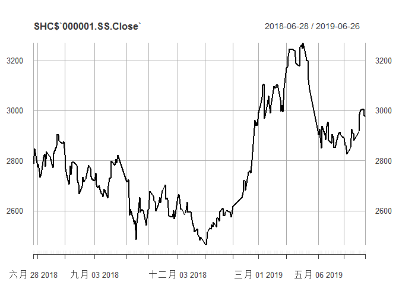

```r
# R scripts for exercise 1.2
plot(SHC$`000001.SS.Close`)
```

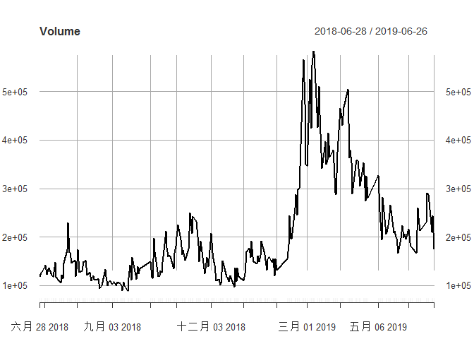

```r
plot(SHC$`000001.SS.Volume`,main="Volume")
```

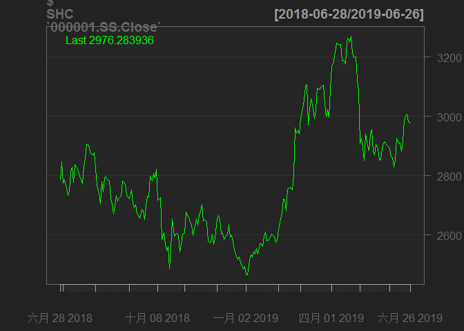

```r
chartSeries(SHC$`000001.SS.Close`,type = "line")
```

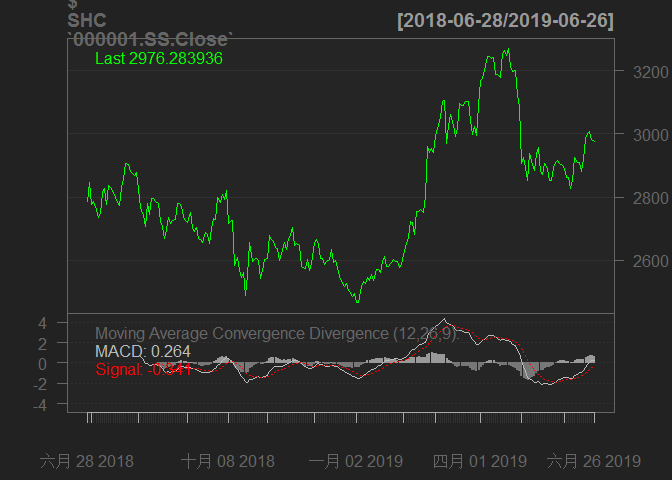

```r
addMACD()
```

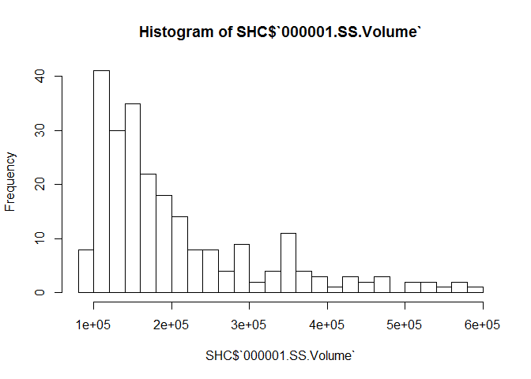

```r
hist(SHC$`000001.SS.Volume`,breaks = 25)
```

```r
png("close.png")
plot(SHC$`000001.SS.Close`)
dev.off()
```

```r
pdf("hist_Volume.pdf")
hist(SHC$`000001.SS.Volume`,breaks = 25)
dev.off()
```

## 4.3 R scripts for exercise 1.3

```r
# R scripts for exercise 1.3
daily_rets <- dailyReturn(SHC)
weekly_rets <- periodReturn(SHC,period = "weekly")
monthly_rets <- periodReturn(SHC,period = "monthly")

View(daily_rets)
print(head(weekly_rets))
```

```
##            weekly.returns
## 2018-06-29   0.0169698372
## 2018-07-06  -0.0351859004
## 2018-07-13   0.0305599125
## 2018-07-20  -0.0006757194
## 2018-07-27   0.0156658723
## 2018-08-03  -0.0463360096
```

```r
seriesHi(daily_rets)
```

```
##            daily.returns
## 2019-02-25    0.05600721
```

```r
seriesLo(weekly_rets)
```

```
##            weekly.returns
## 2018-10-12    -0.07600511
```

```r
seriesHi(monthly_rets)
```

```
##            monthly.returns
## 2019-02-28       0.1378882
```

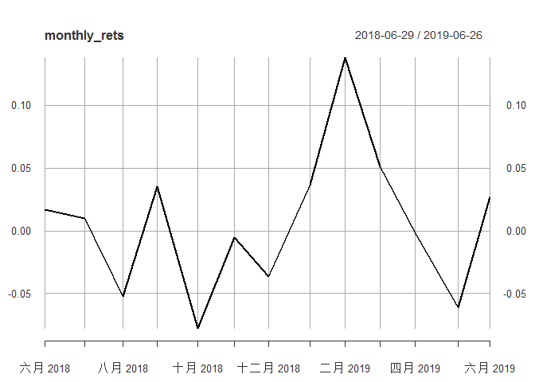

```r
plot(monthly_rets)
```

```r
write.xlsx(cbind(daily_rets,weekly_rets),file = "SHCI.xlsx",sheetName = "SHC_return",append = T)
```

## 4.4 R scripts for exercise 1.4

```r
# R scripts for exercise 1.4
UST10YR = getSymbols("DGS10",src="FRED",auto.assign = F)
UST10YR["1980-10-15"]
```

```
##            DGS10
## 1980-10-15 11.29
```

```r
UST10YR["1995-05"]
```

```
##            DGS10
## 1995-05-01  7.09
## 1995-05-02  7.04
## 1995-05-03  6.96
## 1995-05-04  6.85
## 1995-05-05  6.69
## 1995-05-08  6.70
## 1995-05-09  6.61
## 1995-05-10  6.66
## 1995-05-11  6.68
## 1995-05-12  6.67
## 1995-05-15  6.62
## 1995-05-16  6.57
## 1995-05-17  6.53
## 1995-05-18  6.61
## 1995-05-19  6.61
## 1995-05-22  6.63
## 1995-05-23  6.57
## 1995-05-24  6.44
## 1995-05-25  6.39
## 1995-05-26  6.40
## 1995-05-29    NA
## 1995-05-30  6.30
## 1995-05-31  6.30
```

```r
UST10YR["2000-01-18::2000-02-10"] # UST10YR["2000-01-18/2000-02-10"]
```

```
##            DGS10
## 2000-01-18  6.75
## 2000-01-19  6.73
## 2000-01-20  6.79
## 2000-01-21  6.79
## 2000-01-24  6.69
## 2000-01-25  6.70
## 2000-01-26  6.69
## 2000-01-27  6.68
## 2000-01-28  6.66
## 2000-01-31  6.68
## 2000-02-01  6.62
## 2000-02-02  6.60
## 2000-02-03  6.49
## 2000-02-04  6.53
## 2000-02-07  6.64
## 2000-02-08  6.59
## 2000-02-09  6.56
## 2000-02-10  6.67
```

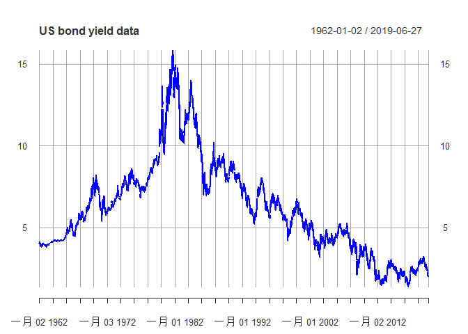

```r
write.xlsx(SHC,file="UST10YR.xlsx", sheetName="UST10YR")
plot(UST10YR, main="US bond yield data", col="blue")
```

```r
dim(UST10YR)
```

```
## [1] 14998     1
```

```r
max(UST10YR,na.rm=T)
```

```
## [1] 15.84
```

```r
min(UST10YR,na.rm = T)
```

```
## [1] 1.37
```

```r
mean(UST10YR,na.rm = T)
```

```
## [1] 6.155319
```

```r
UST10YR["1980-04-25"]
```

```
##            DGS10
## 1980-04-25 10.95
```

```r
mean(UST10YR["2019-03"])
```

```
## [1] 2.570952
```

```r
max(UST10YR["2018-02-22::2018-03-10"]) # max(UST10YR["2018-02-22/2018-03-10"])
```

```
## [1] 2.92
```

## 4.5 R scripts for exercise 1.5

```r
AAA = getSymbols("AAA",src="FRED",auto.assign = F)
BAA = getSymbols("BAA",src="FRED",auto.assign = F)
spread = BAA - AAA
yld_data = merge(AAA, BAA, spread)
head(yld_data)
```

```
##             AAA  BAA BAA.1
## 1919-01-01 5.35 7.12  1.77
## 1919-02-01 5.35 7.20  1.85
## 1919-03-01 5.39 7.15  1.76
## 1919-04-01 5.44 7.23  1.79
## 1919-05-01 5.39 7.09  1.70
## 1919-06-01 5.40 7.04  1.64
```

```r
colnames(yld_data)[1]="AAA_yields"
colnames(yld_data)[2]="BAA_yields"
colnames(yld_data)[3]="spread"
time(yld_data)[spread==3.38] #time(spread)[spread==3.38]
```

```
## [1] "2008-12-01"
```

```r
periodicity(yld_data)
```

```
## Monthly periodicity from 1919-01-01 to 2019-05-01
```

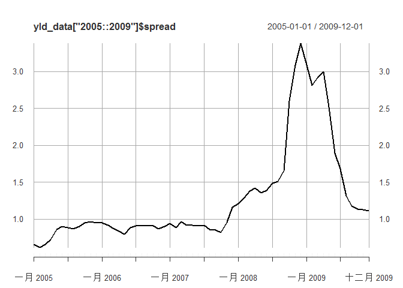

```r
plot(yld_data["2005::2009"]$spread) # plot(yld_data["2005/2009"]$spread)
```

```r
summary(yld_data)
```

```
##      Index              AAA_yields       BAA_yields         spread
##  Min.   :1919-01-01   Min.   : 2.460   Min.   : 2.940   Min.   :0.32
##  1st Qu.:1944-02-01   1st Qu.: 3.740   1st Qu.: 4.850   1st Qu.:0.71
##  Median :1969-03-01   Median : 4.980   Median : 6.320   Median :0.95
##  Mean   :1969-03-01   Mean   : 5.741   Mean   : 6.921   Mean   :1.18
##  3rd Qu.:1994-04-01   3rd Qu.: 7.390   3rd Qu.: 8.390   3rd Qu.:1.44
##  Max.   :2019-05-01   Max.   :15.490   Max.   :17.180   Max.   :5.64
```

```r
max(yld_data["2009"]$spread)
```

```
## [1] 3.09
```

```r
min(yld_data["/2000"]$BAA_yields)
```

```
## [1] 2.94
```

```r
time(yld_data)[AAA==3.5] #time(AAA)[AAA==3.5]
```

```
## [1] "2012-11-01" "2016-06-01"
```

```r
cor(yld_data["1980/2000"]$AAA_yields,yld_data["1980/2000"]$BAA_yields)
```

```
##            BAA_yields
## AAA_yields  0.9951595
```

```r
cor(yld_data["2015/"]$AAA_yields,yld_data["2015/"]$BAA_yields)
```

```
##            BAA_yields
## AAA_yields  0.8050581
```

## 4.6 R scripts for exercise 2.1

```r
# install.packages("PerformanceAnalytics")
# library(PerformanceAnalytics)
SHC = getSymbols("000001.SS",src="yahoo",from="2018-06-28",to="2019-06-26",auto.assign = F)
daily_rets <- dailyReturn(SHC)
weekly_rets <- periodReturn(SHC,period = "weekly")
VaR(daily_rets, p=0.95,method = "historical")
```

```
##     daily.returns
## VaR   -0.02083712
```

```r
VaR(weekly_rets, p=0.95,method = "historical")
```

```
##     weekly.returns
## VaR    -0.04708028
```

## 4.7 R scripts for exercise 3.1

```r
tickers = c("VALE3.SA","PETR4.SA","CMIG4.SA")
weights = c(0.35, 0.35, 0.30)
getSymbols(tickers,from="2018-06-20", to="2019-06-20", auto.assign = T)
```

```
## [1] "VALE3.SA" "PETR4.SA" "CMIG4.SA"
```

```r
port.returns = merge(dailyReturn(VALE3.SA),dailyReturn(PETR4.SA),dailyReturn(CMIG4.SA))
colnames(port.returns)[1]="VALE3.SA"
colnames(port.returns)[2]="PETR4.SA"
colnames(port.returns)[3]="CMIG4.SA"
VaR(port.returns, p=0.95, weights= weights, portfolio_method="component", method="historical")
```

[output not shown]

# 5 Quandl

- `Quandl` is a package used to download financial data. The Quandl package functions use the **Quandl API**. Optional Quandl API query parameters can be passed into each function. For more information on supported query parameters, please see the [Quandl API documentation page](https://docs.quandl.com/).
- Before getting data using Quandl, `Quandl` package should be installed.

```r
# install.packages("Quandl")
# library(Quandl)
# library(xts)
```

- Download the exchange rate of euro against USD, CHF, GBP, JPY, RUB, CAD, AUD. The following commands specify how to select a particular time series and analyze the period.

```r
currencies<-c("USD","CHF","GBP","JPY","RUB","CAD","AUD")
currencies<-paste("CURRFX/EUR", currencies, sep="")
currency_ts<-lapply(as.list(currencies), Quandl, start_date="2005-01-01", end_date="2013-06-07", type="xts")
```

- Next, use `matplot()` to plot the changes of USD, GBP, CAD and AUD.

```r
Q<-cbind(currency_ts[[1]]$Rate, currency_ts[[3]]$Rate, currency_ts[[6]]$Rate, currency_ts[[7]]$Rate)
matplot(Q, type="l", xlab="", ylab="", main="USD, GBP, CAD, AUD",
        xaxt="n", yaxt="n")
ticks=axTicksByTime(currency_ts[[1]])
abline(v=ticks, h=seq(min(Q,na.rm = T), max(Q,na.rm = T), length=5), col="grey", lty=4)
axis(1, at=ticks, labels=names(ticks))
axis(2, at=seq(min(Q,na.rm = T), max(Q,na.rm = T), length=5), labels=round(seq(min(Q,na.rm = T),max(Q,na.rm = T), length=5), 1))
legend("topright", legend = c("USD/EUR", "GBP/EUR","CAD/EUR","AUD/EUR"), col=1:4, pch=19)
```

[output not shown]